# R Notebook - Airbnb Sevilla

# 4. Análisis Grupal

## 4.1. Segmentación del Mercado

Hipótesis planteada:  
*¿Podemos identificar clústeres de comportamiento que demuestren que el mercado de Airbnb se estructura por modelos de negocio y estrategias financieras y no por barrios?*

Queremos comprobar si la realidad del mercado ignora las fronteras del mapa. Por ejemplo, buscamos identificar si existen auténticos “hoteles encubiertos” o alojamientos de lujo operando en barrios periféricos y de rentas más bajas; o si, por el contrario, encontramos habitaciones de bajo coste y altísima rotación camufladas en los distritos supuestamente más exclusivos de la ciudad.

Para descubrir estas realidades ocultas tras los precios, la disponibilidad y el volumen de reservas, aplicaremos técnicas de aprendizaje automático no supervisado (**Clustering K-Means**). Al no indicarle al algoritmo en qué barrio está cada piso, obligaremos a la matemática a agrupar los alojamientos basándose **única y exclusivamente en su rendimiento económico y operativo**.

```r
library(cluster)
library(factoextra)
# 1. SELECCIÓN DE VARIABLES
df_cluster <- df_eda %>%
  select(id, neighbourhood_group_cleansed, neighbourhood_cleansed,
         price, accommodates, reviews_per_month,
         availability_365, calculated_host_listings_count,
         latitude, longitude) %>%
  drop_na() # K-Means da error si hay algún NA residual en estas columnas

# elegimos solo las variables matemáticas para el kmeans
datos_kmeans <- df_cluster %>%
  select(price, accommodates, reviews_per_month,
         availability_365, calculated_host_listings_count)

# estandarizamos para que el precio-hasta 1000 no pise a reviews_per_month(0-5)
datos_escalados <- scale(datos_kmeans)
```

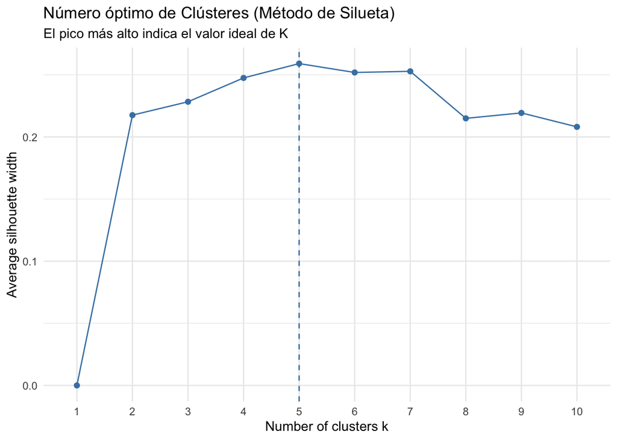

```r
# 2. ANÁLISIS DE SILHOUETTE
fviz_nbclust(datos_escalados, kmeans, method = "silhouette") +
  theme_minimal() +
  labs(title = "Número óptimo de Clústeres (Método de Silueta)",
       subtitle = "El pico más alto indica el valor ideal de K")
```

```r
# 3. APLICAMOS EL ALGORITMO K-MEANS k=5
set.seed(123)
modelo_km_5 <- kmeans(datos_escalados, centers = 5, nstart = 25)

# Añadimos la columna al dataset
df_cluster$Cluster <- as.factor(modelo_km_5$cluster)

perfiles_cluster_5 <- df_cluster %>%
  group_by(Cluster) %>%
  summarise(
    Precio_Medio = round(mean(price), 1),
    Plazas_Medias = round(mean(accommodates), 1),
    Rotacion_Mes = round(mean(reviews_per_month), 2),
    Disponibilidad = round(mean(availability_365), 0),
    Anuncios_por_Host = round(mean(calculated_host_listings_count), 1),
    Total_Pisos = n()
  ) %>%
  arrange(Precio_Medio)

print(perfiles_cluster_5)
```

```
## # A tibble: 5 × 7
##   Cluster Precio_Medio Plazas_Medias Rotacion_Mes Disponibilidad
##   <fct>          <dbl>         <dbl>        <dbl>          <dbl>
## 1 4               110.           3.5         4.49            160
## 2 1               120.           3.5         1.05             89
## 3 3               138.           3.6         1.01            284
## 4 2               149.           4           1.83            217
## 5 5               380.           7.1         1.38            214
## # ℹ 2 more variables: Anuncios_por_Host <dbl>, Total_Pisos <int>
```

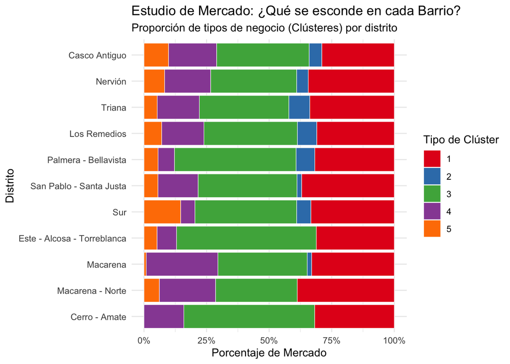

```r
# 5. GRÁFICO BARRIO VS CLÚSTER
ggplot(df_cluster, aes(x = reorder(neighbourhood_group_cleansed, price, median), fill = Cluster)) +
  geom_bar(position = "fill", color = "white", linewidth = 0.2) +
  coord_flip() + # Barras horizontales para leer bien los nombres
  scale_y_continuous(labels = scales::percent) +
  scale_fill_brewer(palette = "Set1") + # Cambia los colores si quieres
  theme_minimal() +
  labs(title = "Estudio de Mercado: ¿Qué se esconde en cada Barrio?",
       subtitle = "Proporción de tipos de negocio (Clústeres) por distrito",
       x = "Distrito",
       y = "Porcentaje de Mercado",
       fill = "Tipo de Clúster")
```

Para que nuestra segmentación de mercado sea objetiva, hemos dejado que la propia estructura de los datos nos revele su división natural, en lugar de forzar al algoritmo a buscar un número arbitrario de grupos (como podrían ser los 11 distritos administrativos que compararemos más adelante).

Para lograr esto, hemos aplicado el **Análisis de Silueta (Silhouette Index)**. Esta técnica de validación evalúa el rendimiento del clustering midiendo dos factores clave para cada posible valor de $k$:

1. **Cohesión:** Qué tan similares son los alojamientos dentro de un mismo grupo.
2. **Separación:** Qué tan bien diferenciados están de los alojamientos de los demás grupos.

El algoritmo nos indicó que el pico máximo de rendimiento (el punto donde los grupos son más sólidos y diferentes entre sí) se encuentra exactamente en $k=5$.

**Aplicación al Modelo K-Means:**

Basándonos en este criterio estrictamente matemático, hemos entrenado nuestro modelo definitivo de K-Means forzando la creación de 5 centros. Esto nos garantiza que los cinco perfiles resultantes no son una agrupación casual, sino la **estructura económica real y estadísticamente robusta** que subyace en el mercado inmobiliario turístico de la ciudad.

Una vez consolidados nuestros 5 modelos de negocio mediante el índice de silueta, nos surgió la curiosidad de segmentar haciendo obligatoria la k igual al numero de distritos definidos, para responder definitivamente a nuestra hipótesis principal: *¿Es verdaderamente el modelo de negocio independiente de la zona, o estamos ignorando la importancia de los barrios?*

Para analizar esta cuestión, diseñamos un experimento de control. El planteamiento fue el siguiente: si el comportamiento económico de un piso dependiera puramente de su ubicación, forzando al algoritmo a generar exactamente **11 clústeres** (coincidiendo con los 11 distritos administrativos de Sevilla), debería ser capaz de “montar” el mapa político de la ciudad basándose solo en los datos.

El **objetivo** de esta comparativa es comprobar si al darle al algoritmo el mismo número de opciones que distritos, cada barrio se asignaba a un clúster único o si por el contrario, los distritos se fragmentaban.

Esto es clave porque nos permite demostrar empíricamente si las fronteras que vemos en los mapas (los códigos postales) tienen algún valor real a nivel financiero y operativo dentro de la plataforma Airbnb, o si son meramente un constructo administrativo que el mercado turístico ignora por completo.

A continuación, analizamos los resultados visuales de este experimento:

```r
set.seed(123)
modelo_km_11 <- kmeans(datos_escalados, centers = 11, nstart = 25)
```

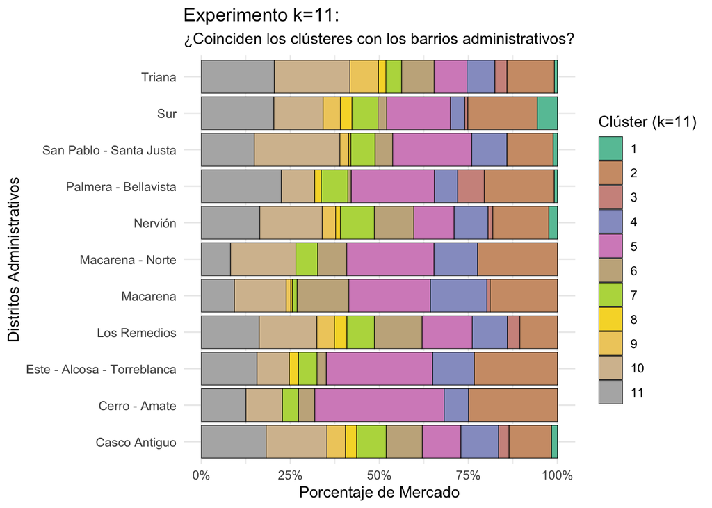

```r
df_cluster$Cluster_11 <- as.factor(modelo_km_11$cluster)

# GRÁFICO: DISTRITOS VS CLÚSTERES
ggplot(df_cluster, aes(x = neighbourhood_group_cleansed, fill = Cluster_11)) +
  geom_bar(position = "fill", color = "black", linewidth = 0.2) +
  coord_flip() +
  scale_y_continuous(labels = scales::percent) +
  # Usamos una paleta con muchos colores porque ahora tenemos 11 grupos
  scale_fill_manual(values = colorRampPalette(RColorBrewer::brewer.pal(8, "Set2"))(11)) +
  theme_minimal() +
  labs(title = "Experimento k=11:",
       subtitle = "¿Coinciden los clústeres con los barrios administrativos?",
       x = "Distritos Administrativos",
       y = "Porcentaje de Mercado",
       fill = "Clúster (k=11)") +
  theme(legend.position = "right")
```

**El Mito de los barrios (k=11)**

Para validar la segmentación de 5 modelos de negocio, se planteó una prueba de refutación:

Si forzamos al algoritmo a buscar 11 clústeres,  
¿será capaz de mapear exactamente los 11 distritos de Sevilla?

Los resultados del gráfico k=11 rechaza esta hipótesis claramente:

- **Hiper-fragmentación por distrito:** En lugar de obtener barras de un solo color sólido (lo que indicaría que cada barrio tiene un comportamiento único y uniforme), observamos que todos los distritos están fragmentados en diferentes clusteres matemáticos.

  > **Conclusión:** La gran mezcla de clusteres en el experimento de $k=11$ demuestra que **la geografía administrativa no dicta el modelo de negocio**. Un alojamiento no se comporta de una manera determinada simplemente por pertenecer al distrito de “San Pablo” o “Los Remedios”. Las verdaderas fronteras del mercado en Sevilla son invisibles. Podríamos deducir que están definidas por estrategias de inversión (similares a los 5 perfiles definidos en el primer experimento), las cuales conviven y compiten de forma superpuesta incluso en las mismas calles de sevilla.

### 4.1.1.Visualización avanzada de clustering

Hemos analizado un poco más en detalle las relaciones entre diferentes variables que consideramos interesantes ampliar su estudio, con los 2 gráficos siguientes:

### Análisis de Distribución de Precios según el modelo de Negocio

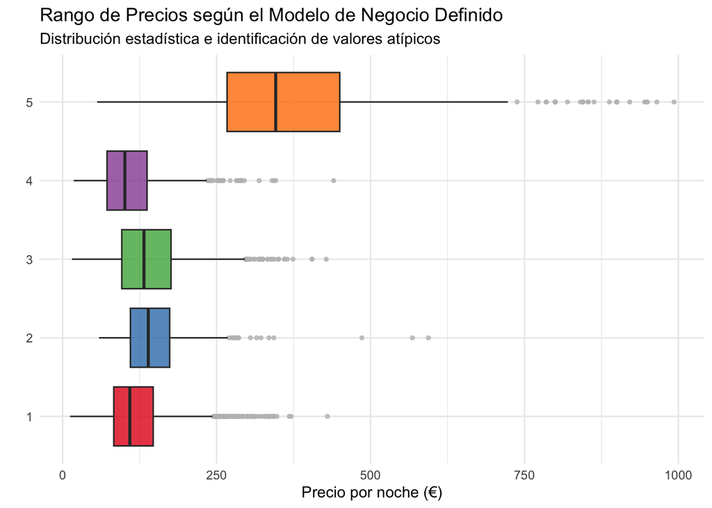

```r
# GRÁFICO 2: DISTRIBUCIÓN DE PRECIOS POR CLUSTER (K=5)
ggplot(df_cluster, aes(x = Cluster, y = price, fill = Cluster)) +
  geom_boxplot(alpha = 0.8, outlier.color = "grey", outlier.size = 1) +
  scale_fill_brewer(palette = "Set1") +
  coord_flip() + # Barras horizontales
  theme_minimal() +
  labs(title = "Rango de Precios según el Modelo de Negocio Definido",
       subtitle = "Distribución estadística e identificación de valores atípicos",
       x = "",
       y = "Precio por noche (€)") +
  theme(legend.position = "none")
```

### Análisis de Estrategia Comercial: Matriz Precio vs. Rotación:

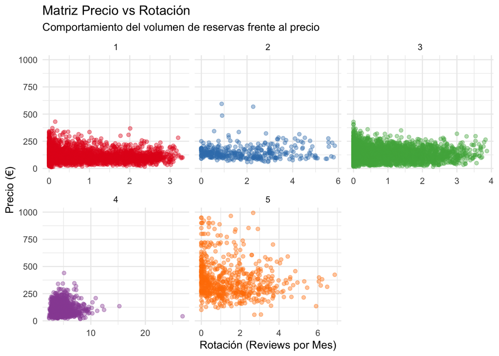

```r
# GRÁFICO 3: MATRIZ DE RENTABILIDAD
ggplot(df_cluster, aes(x = reviews_per_month, y = price, color = Cluster)) +
  geom_point(alpha = 0.4) +
  facet_wrap(~Cluster, scales = "free_x") +
  scale_color_brewer(palette = "Set1") +
  theme_minimal() +
  labs(title = "Matriz Precio vs Rotación",
       subtitle = "Comportamiento del volumen de reservas frente al precio",
       x = "Rotación (Reviews por Mes)",
       y = "Precio (€)") +
  theme(legend.position = "none")
```

### Conclusiones del K-Means: Estudio del Mercado por Distritos

A través de la segmentación por clustering (K-Means) y el análisis de las variables operativas y financieras, hemos dado respuesta a nuestra hipótesis inicial, contrastando que la realidad del mercado de alojamientos en Sevilla es mucho más compleja que el simple “estándar del barrio”.

Las conclusiones clave de nuestro estudio son:

**1. El Mito de la Geografía Administrativa (K=5 vs K=11)** El experimento de refutación forzando 11 clústeres demostró una hiper-fragmentación en todos los distritos, confirmando que las fronteras administrativas (los barrios) no dictan el comportamiento económico de un inmueble. En su lugar, hemos identificado que el mercado real se divide en **5 modelos de negocio** (*Alta Rotación, Particular Ocasional, Media/Larga Estancia, Macro-Agencias* y *Lujo*). Estos perfiles compiten y se superponen en las mismas calles: un piso en el centro puede ser una “habitación para salir del paso” y el de al lado un ático gestionado por un fondo de inversión con lógicas financieras completamente opuestas.

> **Resolución de la Hipótesis:** Definitivamente, **sí podemos identificar clusteres que rompen con el estándar de su zona**. Nuestro análisis demuestra que detrás de un simple “precio por noche” en Airbnb se esconde una compleja estructura. El mercado no se define por “barrios caros y baratos”, sino por estrategias de inversión, demostrando que la profesionalización, la disponibilidad y la rotación son los verdaderos motores del éxito inmobiliario turístico en la ciudad.

## 4.2. Determinantes del Precio

¿Somos capaces de calcular el precio justo de cada alojamiento y detectar matemáticamente qué pisos están inflando su valor aprovechando el turismo?

```r
library(tidyverse)
library(broom)
library(car)
library(lmtest)
listings_4_2 <- read.csv("./csv/listings_preprocesado.csv")
```

### 4.2.1 Entrenamiento del modelo de regresión

Para dar respuesta a esta pregunta hemos decidido utilizar un modelo de **Regresión Lineal Generalizado (GLM)** con distribucción Gamma y enlace logarítmico. Este enfoque nos permite evitar que el modelo prediga precios negativos y para entender que los extras como son la piscina o ubicación no suman una cantidad fija sino un porcentaje sobre el precio base.

```r
# Modelo explicativo base
modelo_precio <- glm(price ~ neighbourhood_cleansed +
                      room_type +
                      accommodates +
                      bathrooms +
                      has_pool +
                      has_ac +
                      review_scores_rating,
                     family = Gamma(link = "log"),
                    data = listings_4_2)

summary(modelo_precio)
```

```
##
## Call:
## glm(formula = price ~ neighbourhood_cleansed + room_type + accommodates +
##     bathrooms + has_pool + has_ac + review_scores_rating, family = Gamma(link = "log"),
##     data = listings_4_2)
##
## Coefficients:
##                                                                                     Estimate
## (Intercept)                                                                         4.033642
## neighbourhood_cleansedAlfalfa                                                       0.640557
## neighbourhood_cleansedAmate                                                        -0.590712
## neighbourhood_cleansedan Roque                                                      0.446756
## neighbourhood_cleansedArenal                                                        0.751418
## neighbourhood_cleansedAvda. de la Paz                                              -0.624396
## neighbourhood_cleansedBami                                                          0.280685
## neighbourhood_cleansedBarrio León                                                   0.342885
## neighbourhood_cleansedBda. de Pineda                                                0.534745
## neighbourhood_cleansedBda. Pino Montano                                             0.113685
## neighbourhood_cleansedBegoña, Santa Catalina                                       -0.257628
## neighbourhood_cleansedBellavista                                                    0.226510
## neighbourhood_cleansedCampos de Soria                                              -0.307573
## neighbourhood_cleansedCarretera de Carmona, María Auxiliadora, Fontanal             0.253370
## neighbourhood_cleansedCisneo Alto, Santa María de Graccia                          -0.073903
## neighbourhood_cleansedCiudad Jardín                                                 0.142680
## neighbourhood_cleansedColores, Entreparques                                         0.177189
## neighbourhood_cleansedConsolación                                                  -0.186322
## neighbourhood_cleansedCruz Roja, Capuchinos                                         0.075899
## neighbourhood_cleansedDoctor Barraquer, G. Renfe, Policlínico                       0.588344
## neighbourhood_cleansedEl Cano, Los Bermejales                                       0.050103
## neighbourhood_cleansedEl Carmen                                                    -0.108417
## neighbourhood_cleansedEl Cerro                                                     -0.159750
## neighbourhood_cleansedEl Gordillo                                                  -0.824505
## neighbourhood_cleansedEl Juncal, Híspalis                                           0.526344
## neighbourhood_cleansedEl Plantinar                                                  0.660484
## neighbourhood_cleansedEl Porvenir                                                   0.292720
## neighbourhood_cleansedEl Rocío                                                     -0.228640
## neighbourhood_cleansedEl Tardón, El Carmen                                          0.304390
## neighbourhood_cleansedEl Torrejón, El Cerezo                                       -0.248151
## neighbourhood_cleansedEncarnación, Regina                                           0.585733
## neighbourhood_cleansedFelipe II, Los Diez Mandamientos                             -0.230007
```

[output cut: 517 more lines]

```
## accommodates                                                                       ***
## bathrooms                                                                          ***
## has_pool                                                                           ***
## has_ac
## review_scores_rating                                                               .
## ---
## Signif. codes:  0 '***' 0.001 '**' 0.01 '*' 0.05 '.' 0.1 ' ' 1
##
## (Dispersion parameter for Gamma family taken to be 0.3226572)
##
##     Null deviance: 2636.9  on 7483  degrees of freedom
## Residual deviance: 1479.0  on 7374  degrees of freedom
## AIC: 81792
##
## Number of Fisher Scoring iterations: 7
```

Analizando los resultados que arroja el summary nos podemos dar cuenta de un hallazgo sorprendente, cuanto menos, la mayoría de los barrios que se encuentran en la periferia como son Amate, Bellavista o Pino Montano, muestran p-values muy altos, lo que significa que no tienen un gran impacto en el precio respecto al nivel base. Sin embargo, podemos ver cómo el “Efecto Centro” es drástico. Al convertir los coeficientes logarítmicos en porcentajes (exp(β)−1), descubrimos que en el barrio de Santa Cruz tenemos un sobreprecio del 129% solo por la ubicación, seguidos del Arenal con un 112%. También nos ha parecido curioso que barrios como Triana no tienen un impacto tan extremo, teniendo entre un 52% y un 60% de sobreprecio; esto nos indica que su popularidad supera a su cotización real si lo comparamos con el casco histórico

Con una devianza explicada cercana al 44%, el modelo explica casi la mitad de la varianza de precios solo con variables estructurales. El 56% restante sugiere que factores intangibles como la decoración, la calidad de las fotos o el trato del anfitrión juegan un papel decisivo en la fijación del precio final en plataformas como Airbnb.

### 4.2.2 Diagnóstico y validación

```r
# A. Multicolinealidad (VIF)
# Verificamos que las variables no sean redundantes entre sí
vif_valores <- vif(modelo_precio)
print("--- Valores VIF (Deben ser < 5) ---")
```

```
## [1] "--- Valores VIF (Deben ser < 5) ---"
```

```r
print(vif_valores)
```

```
##                            GVIF  Df GVIF^(1/(2*Df))
## neighbourhood_cleansed 1.452988 101        1.001851
## room_type              1.470277   3        1.066350
## accommodates           1.882531   1        1.372053
## bathrooms              1.611825   1        1.269577
## has_pool               1.078803   1        1.038654
## has_ac                 1.108862   1        1.053025
## review_scores_rating   1.041892   1        1.020731
```

[figure not shown]

```r
par(mar = c(5, 8, 4, 2)) # Ajustar márgenes
barplot(vif_valores, main = "Validación: Factor de Inflación de la Varianza (VIF)",
        horiz = TRUE, col = "steelblue", xlim = c(0, 5), las = 1)
abline(v = 5, col = "red", lty = 2)
```

```r
# B. Heterocedasticidad (Breusch-Pagan)
# Comprobamos si el error es constante
print("--- Test de Breusch-Pagan ---")
```

```
## [1] "--- Test de Breusch-Pagan ---"
```

```r
bptest(modelo_precio)
```

```
##
##  studentized Breusch-Pagan test
##
## data:  modelo_precio
## BP = 226.35, df = 109, p-value = 3.166e-10
```

Antes de interpretar los coeficientes del modelo lo hemos sometido a unos diagnosticos para asegurarnos que cumple con la teoria de la regresion lineal. Un modelo con coeficientes sesgados puede llevarnos a conclusiones de negocios erroneas.

En primer lugar hemos calculado el Factor de Inflacion de la Varianza para detectar redundancia entre las variables predictoras. Como podemos ver todas las variables tienen un VIF muy bajo, que oscila entre 1,04 y 1,88. Esto nos permite llegar a la conclusion de que la independencia es robusta y que nuestras variables aportan informacion unica y no solapada al precio final.

Despues hemos aplicado el test de Breusch-Pagan para confirmar si la varianza del error es constante. Dado que nos encontramos un p-value inferior a 0.05 podemos indicar que el modelo comete errores mas grandes en los pisos caros que en los baratos.No obstante, esta es la razón por la que hemos utilizado un modelo GLM con familia Gamma; este algoritmo asume y corrige matemáticamente esta falta de constancia en la varianza, garantizando que nuestros resultados y conclusiones finales sean totalmente válidos y rigurosos.

### 4.2.3 Interpretación del modelo

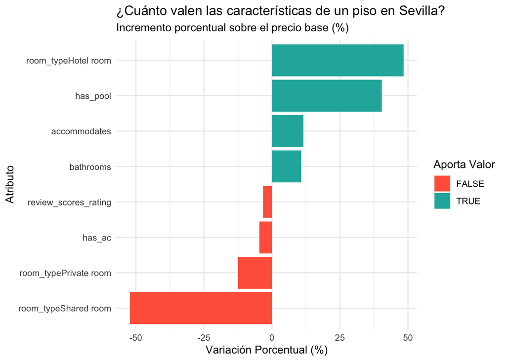

```r
coeficientes <- tidy(modelo_precio) %>%
  filter(term != "(Intercept)") %>%
  filter(!str_detect(term, "neighbourhood")) %>%
  mutate(impacto_pct = (exp(estimate) - 1) * 100) %>%
  arrange(desc(impacto_pct))

ggplot(coeficientes, aes(x = reorder(term, impacto_pct), y = impacto_pct, fill = impacto_pct > 0)) +
  geom_bar(stat = "identity") +
  coord_flip() +
  theme_minimal() +
  scale_fill_manual(values = c("tomato", "lightseagreen")) + # Colores más académicos
  labs(title = "¿Cuánto valen las características de un piso en Sevilla?",
       subtitle = "Incremento porcentual sobre el precio base (%)",
       x = "Atributo", y = "Variación Porcentual (%)", fill = "Aporta Valor")
```

Tras analizar los coeficientes, podemos ver que, aunque creamos que la ubicación de un piso es el factor más determinante, no es este el único.

Como podemos ver en la gráfica anterior, el factor que más dispara el precio es la tipología de alojamiento: si es una **habitación de hotel** se añade un **sobrecoste del 48%** frente al apartamento estándar. Esto confirma la existencia de una oferta que se encuentra en manos de profesionales, las cuales operan con un esquema de precios muy superior.

También podemos observar que la piscina destaca entre los extras, aumentando el precio en un 40%. Esto nos indica que en Sevilla, la piscina no es un simple complemento, sino un activo premium indiscutible que encarece drásticamente el precio de ese alojamiento.

Por cada persona extra que cabe en el piso, el precio sube un 11,5%, y por cada baño adicional suma un 10,7% sobre el valor base. En el lado opuesto, alquilar una habitación privada o compartida penaliza el precio cayendo entre un 12% y un 52%.

Podemos observar en la imagen que el modelo arroja un coeficiente negativo para el aire acondicionado (además de ser estadísticamente no significativo, como vimos en el summary anterior). Esto es debido a que en Sevilla el aire acondicionado está presente en casi el 95% de los alojamientos por lo que su presencia ya no sube el precio (es un requisito básico), pero los pisos que explícitamente lo anuncian como su gran extra suelen ser de gama media-baja intentando destacar, mientras que los pisos de gama alta esto lo dan por hecho.

### 4.2.4 Detección de anomalías

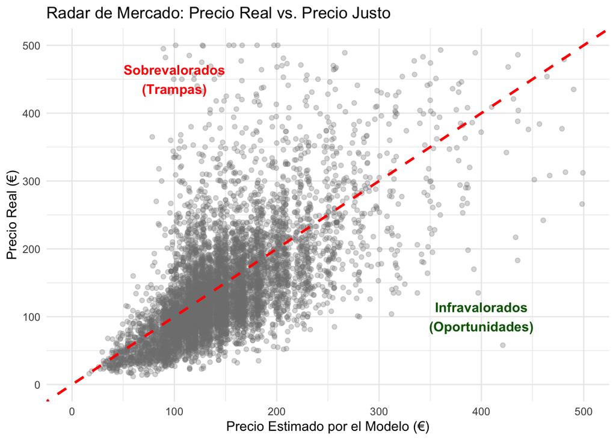

```r
# Calculamos predicciones y residuos
listings_4_2$precio_justo <- predict(modelo_precio, listings_4_2, type = "response")
listings_4_2$sobreprecio <- listings_4_2$price - listings_4_2$precio_justo

# A. Gráfico Radar (Scatter Plot)
ggplot(listings_4_2, aes(x = precio_justo, y = price)) +
  geom_point(alpha = 0.3, color = "gray50") +
  geom_abline(intercept = 0, slope = 1, color = "red", linetype = "dashed", size = 1) +
  annotate("text", x = 100, y = 450, label = "Sobrevalorados\n(Trampas)", color = "red", fontface="bold") +
  annotate("text", x = 400, y = 100, label = "Infravalorados\n(Oportunidades)", color = "darkgreen", fontface="bold") +
  theme_minimal() +
  labs(title = "Radar de Mercado: Precio Real vs. Precio Justo",
       x = "Precio Estimado por el Modelo (€)", y = "Precio Real (€)") +
  xlim(0, 500) + ylim(0, 500)
```

```r
# B. Tablas de Casos Extremos
top_inflados <- listings_4_2 %>%
  arrange(desc(sobreprecio)) %>%
  select(id, neighbourhood_cleansed, price, precio_justo, sobreprecio) %>%
  head(10)

top_chollos <- listings_4_2 %>%
  arrange(sobreprecio) %>%
  select(id, neighbourhood_cleansed, price, precio_justo, sobreprecio) %>%
  head(10)

print("--- Top 10 Trampas Turísticas ---")
```

```
## [1] "--- Top 10 Trampas Turísticas ---"
```

```r
print(top_inflados)
```

```
##              id neighbourhood_cleansed price precio_justo sobreprecio
## 1  8.766069e+17                  Feria   950    130.75173    819.2483
## 2  1.189635e+18                  Feria   900     92.14655    807.8534
## 3  9.041080e+17                  Feria   900    136.97825    763.0218
## 4  1.114446e+18               an Roque   900    168.92329    731.0767
## 5  8.819019e+06          San Bartolomé   900    180.52660    719.4734
## 6  1.491067e+18                Alfalfa   853    134.64251    718.3575
## 7  1.478324e+18    Encarnación, Regina   841    140.83464    700.1654
## 8  8.273759e+17    Encarnación, Regina   800    100.21224    699.7878
## 9  6.765653e+17                Alfalfa   800    105.91436    694.0856
## 10 6.686400e+17                 Arenal   800    119.46386    680.5361
```

```r
print("--- Top 10 Oportunidades ---")
```

```
## [1] "--- Top 10 Oportunidades ---"
```

```r
print(top_chollos)
```

```
##              id neighbourhood_cleansed price precio_justo sobreprecio
## 1  4.783315e+06                  Museo   263     890.1262   -627.1262
## 2  1.145272e+07                Alfalfa   350     920.9534   -570.9534
## 3  5.614541e+17                Alfalfa   436     952.1152   -516.1152
## 4  8.593089e+17                 Arenal   605    1111.8851   -506.8851
## 5  1.145681e+18             La Florida    56     560.5523   -504.5523
## 6  1.141314e+18             Santa Cruz   993    1394.2240   -401.2240
## 7  1.207232e+18     Huerta de la Salud   378     757.9256   -379.9256
## 8  1.135258e+18          San Bartolomé    58     420.9644   -362.9644
## 9  1.767395e+07          San Bartolomé   549     903.9702   -354.9702
## 10 3.443300e+07          San Bartolomé   412     726.5464   -314.5464
```

En la gráfica anterior tenemos la proyección del “Precio Justo” contra el “Precio Real”, la línea diagonal roja representa el equilibrio del mercado perfecto.

### 4.2.6 Modelo avanzado con iteracciones

```r
modelo_interaccion <- glm(price ~ neighbourhood_cleansed +
                           accommodates +
                           review_scores_rating +
                           has_pool * room_type, # Interacción Clave
                         family = Gamma(link = "log"),
                         data = listings_4_2)

print("--- Resultados del Modelo con Interacción (GLM) ---")
```

```
## [1] "--- Resultados del Modelo con Interacción (GLM) ---"
```

```r
coef_interaccion <- summary(modelo_interaccion)$coefficients
coef_interaccion[grep("pool", row.names(coef_interaccion)), ]
```

```
##                                  Estimate Std. Error   t value     Pr(>|t|)
## has_pool                        0.3274110 0.02443861 13.397286 1.859326e-40
## has_pool:room_typeHotel room   -0.5933260 0.28858953 -2.055951 3.982236e-02
## has_pool:room_typePrivate room  0.2468972 0.08050459  3.066871 2.170956e-03
```

En este apartado planteamos la hipótesis de que el valor de un servicio como es la piscina no es constante, sino que depende de la tipología del alojamiento, es decir, ¿paga el cliente lo mismo por una piscina privada que por una comunitaria cuando alquila una habitación?

Para ello hemos introducido en el modelo un término de iteración **has_pool x room_type**. Como vemos en los resultados, el coeficiente base de contar con piscina (has_pool) arroja un valor de 0.327. Esto significa que, para la categoría de referencia (el apartamento completo estándar), la piscina es un diferenciador absoluto que eleva el precio base de la propiedad en un 38,7% (exp(0.327)−1).

Si observamos los coeficientes de interacción, el modelo revela dinámicas de mercado radicalmente distintas según el tipo de producto:

Por un lado, encontramos una clara anomalía en las habitaciones de hotel, donde vemos un coeficiente de interacción fuertemente negativo (−0.593) y estadísticamente significativo (p<0.05). Esto indica que el modelo penaliza severamente esta combinación. Al sumar el efecto base y la interacción, descubrimos que los hoteles con piscina son porcentualmente más baratos que los que no la tienen. Esto confirma que la categoría hotelera en Airbnb agrupa dos realidades opuestas: los “Hoteles Boutique” del centro histórico (carísimos, pero sin espacio físico para piscina) y cadenas hoteleras u hostales de la periferia (con piscina, pero con precios base mucho más bajos), rompiendo la lógica residencial del dataset.

Por otro lado, el hallazgo más revelador se encuentra en la habitación privada (Private room). Su coeficiente de interacción es netamente positivo (+0.246) y altamente significativo (p<0.01). Si sumamos este efecto al valor base de la piscina, descubrimos que una piscina en una habitación privada eleva su cotización en un 77,5% (exp(0.327+0.246)−1). Esto demuestra que alquilar una habitación con piscina cambia por completo la gama del producto, pasando de un alojamiento puramente económico a una experiencia de lujo compartido (ej. chalets residenciales), justificando un salto porcentual en el precio mucho mayor que en un piso completo.

Como conclusión final, podemos afirmar que la regla de oro de la revalorización por piscina es robusta en el mercado residencial (disparando el precio de pisos y habitaciones), pero sufre un efecto inverso en la oferta hotelera listada en la plataforma, la cual obedece a dinámicas patrimoniales de ubicación en el casco antiguo.

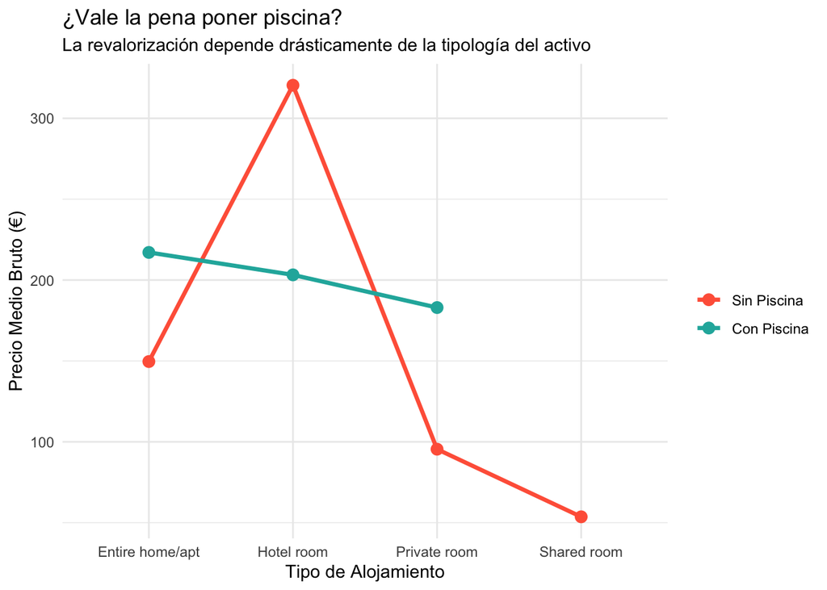

```r
# Calculamos el precio medio según si tiene piscina y el tipo de alojamiento
interaccion_plot <- listings_4_2 %>%
  group_by(room_type, has_pool) %>%
  summarise(precio_medio = mean(price), .groups = 'drop') %>%
  mutate(has_pool = factor(has_pool, labels = c("Sin Piscina", "Con Piscina")))

ggplot(interaccion_plot, aes(x = room_type, y = precio_medio, group = has_pool, color = has_pool)) +
  geom_line(size = 1.2) +
  geom_point(size = 3) +
  theme_minimal() +
  scale_color_manual(values = c("tomato", "lightseagreen")) + # Colores coherentes
  labs(title = "¿Vale la pena poner piscina?",
       subtitle = "La revalorización depende drásticamente de la tipología del activo",
       x = "Tipo de Alojamiento", y = "Precio Medio Bruto (€)", color = "")
```

Hemos generado un gráfico en el que podemos observar cómo varía el precio medio según si aparece piscina en cada tipo de alojamiento.

Observamos una clara correlación positiva en los segmentos residenciales, en ambos casos la línea azul se sitúa por encima de la roja. En cambio, como hemos visto antes en los hoteles, las líneas se cruzan y aparecen hoteles sin piscina con precios mucho más altos que los que tienen piscina.

### 4.2.7 Calculadora de precio justo

A continuación, se presenta un caso de uso: - Ubicación: Triana Oeste - Tipología: Piso completo (Entire home/apt) - Capacidad: 4 personas - Extras: Piscina y aire acondicionado - Calidad Esperada: Calificación de 4.8/5

```r
predecir_precio <- function(barrio, tipo, capacidad, baños, piscina, ac, rating) {
  nuevo_piso <- data.frame(
    neighbourhood_cleansed = barrio,
    room_type = tipo,
    accommodates = capacidad,
    bathrooms = baños,
    has_pool = piscina, # 1 o 0
    has_ac = ac,        # 1 o 0
    review_scores_rating = rating
  )
  prediccion <- predict(modelo_precio, newdata = nuevo_piso, type = "response")

  return(paste0("El precio justo de mercado para este piso es: ", round(prediccion, 2), "€"))
}
# "¿Cuánto debería cobrar por un piso en Triana para 4 personas con piscina?"
print(predecir_precio("Triana Oeste", "Entire home/apt", 4, 1, 1, 1, 4.8))
```

```
## [1] "El precio justo de mercado para este piso es: 169.52€"
```

El algoritmo, aplicando los coeficientes porcentuales del GLM, nos arroja un valor técnico de mercado en torno a los 169€ la noche.

Este valor funciona como precio base. A partir de aquí, el propietario puede tomar decisiones basadas en datos: si decide cobrar 250€, sabrá a ciencia cierta que está exigiendo un sobreprecio de casi el 48% respecto a la media de sus competidores directos, un sobrecoste que deberá justificar con intangibles (interiorismo de lujo, vistas, marca personal). Por el contrario, si decide salir a comercializarlo a 130€, tendrá la seguridad matemática de estar siendo agresivo en precio y estar situado en la zona de oportunidad del mercado, lo que muy probablemente le garantizará llenar el calendario de reservas rápidamente en sus primeros meses.

## 4.3. El “Efecto Giralda”

Para abordar la hipótesis del ‘Efecto Giralda’, comenzamos analizando la distribución espacial de los precios como un continuo geográfico. Al prescindir de las fronteras administrativas de los barrios (que a menudo son arbitrarias y no reflejan la realidad del mercado turístico), buscamos observar si existe un patrón radial de encarecimiento que tenga como epicentro absoluto el principal monumento de la ciudad: la Catedral/Giralda.

Dado que el dataset original solo contenía coordenadas geográficas (latitud/longitud), era imprescindible transformarlas en una métrica de negocio utilizable.

Para ello, hemos aplicado la fórmula de Haversine, calculando la distancia de círculo máximo (en metros) entre cada alojamiento y la Catedral, teniendo en cuenta la curvatura de la Tierra. Gracias a esta nueva variable (distancia_giralda_m), hemos podido acotar el análisis a un radio operativo de 3.000 metros y generar la siguiente visualización de “Calor Radial”:

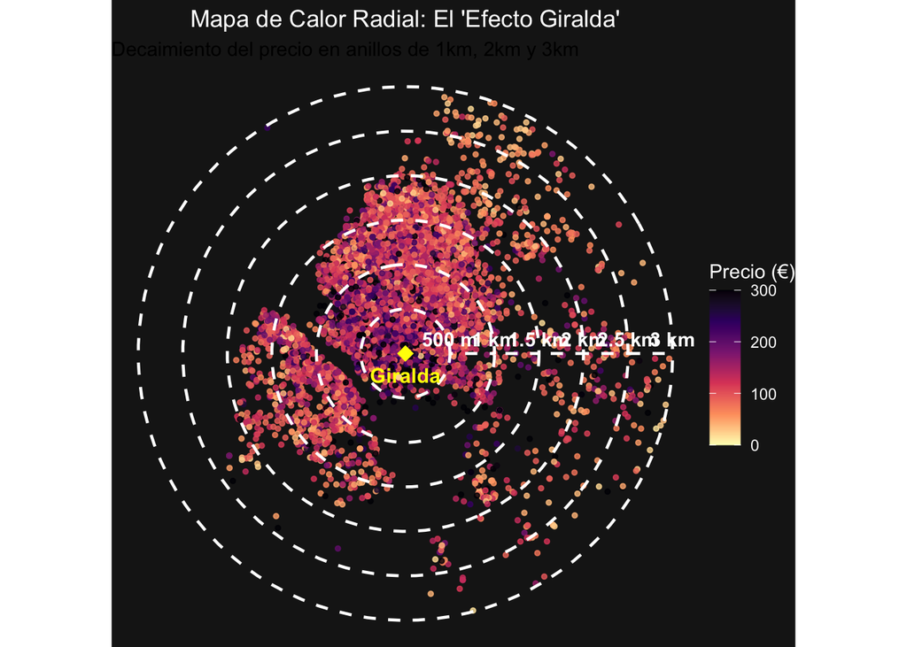

```r
# --- Visualización "Diana" del Efecto Giralda ---

library(dplyr)
library(ggplot2)
library(geosphere) # Necesario para calcular la distancia

# 1. Definimos el centro (Giralda)
centro_giralda <- c(-5.99238, 37.38614)

# 2. CALCULAMOS LA DISTANCIA (El paso que faltaba antes)

df_eda <- df_eda %>%
  rowwise() %>%
  mutate(
    distancia_giralda_m = distHaversine(c(longitude, latitude), centro_giralda)
  ) %>%
  ungroup()

# 3. Ahora sí, creamos df_diana filtrando por esa distancia
df_diana <- df_eda %>%
  filter(distancia_giralda_m <= 3000)

# 4. Generamos los anillos de la diana (1km, 2km, 3km)
crear_anillo <- function(radio_metros, etiqueta) {
  angulos <- seq(0, 2*pi, length.out = 100)
  r_lat <- radio_metros / 111132.95
  r_lon <- radio_metros / (111132.95 * cos(centro_giralda[2] * pi/180))
  data.frame(
    x = centro_giralda[1] + r_lon * cos(angulos),
    y = centro_giralda[2] + r_lat * sin(angulos),
    label = etiqueta
  )
}

anillos <- bind_rows(
  crear_anillo(500, "500 m"),
  crear_anillo(1000, "1 km"),
  crear_anillo(1500, "1.5 km"),
  crear_anillo(2000, "2 km"),
  crear_anillo(2500, "2.5 km"),
  crear_anillo(3000, "3 km")
)

# 5. Pintamos el Mapa
ggplot() +
  geom_point(data = df_diana, aes(x = longitude, y = latitude, color = price),
             size = 1, alpha = 0.8) +
  geom_path(data = anillos, aes(x = x, y = y), color = "white", linetype = "dashed", size = 0.8) +
  geom_text(data = anillos %>% group_by(label) %>% slice(1),
            aes(x = x, y = y, label = label), color = "white", vjust = -0.5, fontface = "bold") +
  annotate("point", x = centro_giralda[1], y = centro_giralda[2], color = "yellow", size = 4, shape = 18) +
  annotate("text", x = centro_giralda[1], y = centro_giralda[2], label = "Giralda",
           vjust = 2, color = "yellow", fontface = "bold", size = 4) +
  scale_color_viridis_c(option = "magma", direction = -1, limits = c(0, 300), oob = scales::squish) +
  coord_quickmap() +
  theme_void() +
  theme(plot.background = element_rect(fill = "gray10", color = NA),
        legend.text = element_text(color = "white"),
        legend.title = element_text(color = "white"),
        plot.title = element_text(color = "white", hjust = 0.5)) +
  labs(title = "Mapa de Calor Radial: El 'Efecto Giralda'",
       subtitle = "Decaimiento del precio en anillos de 1km, 2km y 3km",
       color = "Precio (€)")
```

Como podemos observar en la visualización, los puntos más oscuros (precios más altos) se agrupan formando una densa nube alrededor del marcador amarillo de la Giralda. A medida que nuestra vista se desplaza hacia la periferia, los colores viran hacia tonos más claros, sugiriendo una caída del precio. Sin embargo, esta intuición visual no es suficiente para extraer conclusiones de negocio; necesitamos cuantificar matemáticamente esta pérdida de valor.

Una vez calculada la distancia exacta a la Giralda, procedemos a modelar el decaimiento del valor económico. Para evitar el sesgo introducido por los diferentes tipos de alojamiento, aislaremos el análisis exclusivamente a la categoría ‘Entire home/apt’ y limitaremos el radio de estudio a los primeros 3.000 metros (área de influencia turística). Dado que la caída de precios en bienes raíces rara vez es perfectamente lineal (el precio tiende a estabilizarse en la periferia), utilizaremos una técnica de Regresión No Lineal (LOESS) para capturar la curvatura real del mercado, complementada con un modelo lineal clásico para los primeros 1.000 metros y así responder con precisión a nuestra pregunta de negocio.

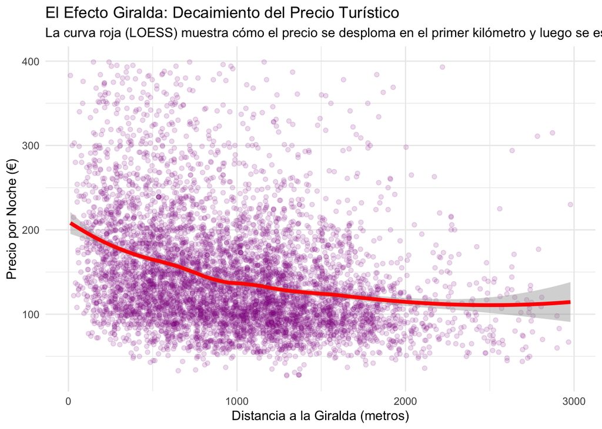

```r
# 1. Filtramos datos para comparar "manzanas con manzanas"
df_giralda <- df_eda %>%
  filter(
    room_type == "Entire home/apt", # Solo pisos completos
    price < 400,                    # Filtramos lujo extremo para ver la tendencia general
    distancia_giralda_m <= 3000     # Analizamos solo los primeros 3 kilómetros
  )

# 2. Visualización del Modelo LOESS
ggplot(df_giralda, aes(x = distancia_giralda_m, y = price)) +
  geom_point(alpha = 0.15, color = "darkmagenta") +
  # Añadimos la curva LOESS para ver la tendencia no lineal
  geom_smooth(method = "loess", color = "red", linewidth = 1.5, span = 0.5) +
  theme_minimal() +
  labs(
    title = "El Efecto Giralda: Decaimiento del Precio Turístico",
    subtitle = "La curva roja (LOESS) muestra cómo el precio se desploma en el primer kilómetro y luego se estabiliza",
    x = "Distancia a la Giralda (metros)",
    y = "Precio por Noche (€)"
  )
```

```r
# 3. Modelo Matemático (Regresión Lineal) para el primer kilómetro
# Queremos saber el dato exacto de cuánto cae por cada 100 metros en la zona más sensible
df_primer_km <- df_giralda %>% filter(distancia_giralda_m <= 1000)
modelo_lineal <- lm(price ~ distancia_giralda_m, data = df_primer_km)

# Extraemos el coeficiente (cuánto cae el precio por cada 1 metro) y lo multiplicamos por 100
caida_por_metro <- coef(modelo_lineal)["distancia_giralda_m"]
caida_por_100m <- caida_por_metro * 100

print(paste("Caída del precio por cada 100 metros en el primer kilómetro:", round(caida_por_100m, 2), "€"))
```

```
## [1] "Caída del precio por cada 100 metros en el primer kilómetro: -6.5 €"
```

Respondiendo a la pregunta planteada: Sí, el ‘Efecto Giralda’ es un fenómeno cuantificable en el mercado de Airbnb en Sevilla. A través de la regresión local (LOESS), hemos descubierto que el comportamiento espacial del precio no es constante, sino que presenta dos fases diferenciadas:

1.(0 - 1.000 metros): En el radio inmediato a la Catedral, la penalización por alejarse es severa. Nuestro modelo de regresión lineal aplicado a este segmento revela que el precio del alquiler de un apartamento completo cae, en promedio, 6,50 € por cada 100 metros que nos alejamos del epicentro. Esto demuestra que en el centro histórico, la ubicación extrema prima sobre el resto de variables.

2.(> 1.500 metros): A partir del kilómetro y medio, la curva roja (LOESS) frena su caída y se estabiliza casi por completo en un suelo de precios base. En este punto, la variable ‘distancia a la Giralda’ pierde todo su poder predictivo frente a las características internas del inmueble (tamaño, piscina, etc).

Impacto de Negocio: El sobrecoste de adquirir una vivienda a menos de 500 metros de la Giralda está justificado por una prima de facturación diaria asegurada. Sin embargo, más allá de la frontera del primer kilómetro, la estrategia óptima para un inversor no es buscar cercanía al centro, sino maximizar el equipamiento (amenities) del piso.